# COSE461 Assignment 4: Neural Machine Translation

### **Due 5:00 PM, Tue Nov 9**

To get started, make a copy of the assignment by clicking File->Save a copy in drive... or 파일->드라이브에 사본 저장. You will need to be logged into a Google account, such as your @korea.ac.kr mail account.

In this assignment, we are going to implement Cherokee-to-English Neural Machine Translator based on RNNs. If you want to know more about the task itself, take a look at [Zhang et al (2020)](https://arxiv.org/abs/2010.04791).

# 1. Neural Machine Translation with RNNs (30 points)

In Machine Translation, our goal is to convert a sentence from the source language (e.g. Cherokee) to the target language (e.g. English). In this assignment, we will implement a sequence-to-sequence (Seq2Seq) network with attention, to build a Neural Machine Translation (NMT) system. In this section, we describe the training procedure for the proposed NMT system, which uses a Bidirectional LSTM Encoder and a Unidirectional LSTM Decoder.

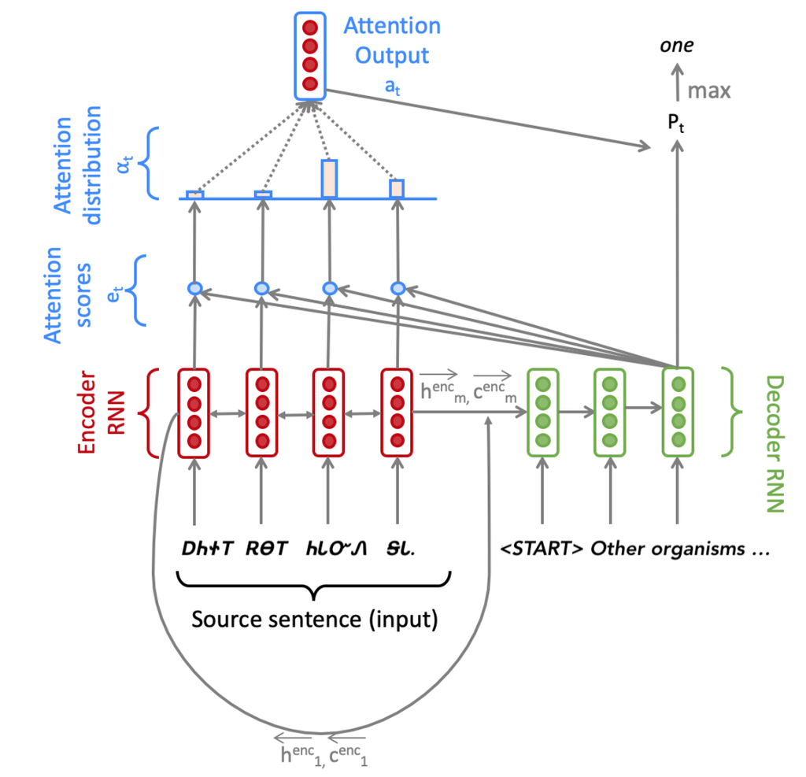

Figure 1: Seq2Seq Model with Multiplicative Attention, shown on the third step of the decoder.

### Model description (training procedure)

Given a sentence in the source language, we look up the subword embeddings from an embeddings matrix, yielding $\mathbf{x}_1,...,\mathbf{x}_m (\mathbf{x}_i\in\mathbb{R}^{e\times 1})$, where $m$ is the length of the source sentence and $e$ is the embedding size. We feed these embeddings to the bidirectional encoder, yielding hidden states and cell states for both the forwards (→) and backwards (←) LSTMs. The forwards and backwards versions are concatenated to give hidden states $\mathbf{h}_{i}^{\text{enc}}$ and cell states $\mathbf{c}_{i}^{\text{enc}}$: \begin{align} \mathbf{h}_{i}^{\text{enc}}&=[\overleftarrow{\mathbf{h}_{i}^{\text{enc}}};\overrightarrow{\mathbf{h}_{i}^{\text{enc}}}]~~\text{where}~~\mathbf{h}_{i}^{\text{enc}}\in\mathbb{R}^{2h\times1},\overleftarrow{\mathbf{h}_{i}^{\text{enc}}},\overrightarrow{\mathbf{h}_{i}^{\text{enc}}}\in\mathbb{R}^{h\times1} & 1\le i \le m\\ \mathbf{c}_{i}^{\text{enc}}&=[\overleftarrow{\mathbf{c}_{i}^{\text{enc}}};\overrightarrow{\mathbf{c}_{i}^{\text{enc}}}]~~\text{where}~~\mathbf{c}_{i}^{\text{enc}}\in\mathbb{R}^{2h\times1},\overleftarrow{\mathbf{c}_{i}^{\text{enc}}},\overrightarrow{\mathbf{c}_{i}^{\text{enc}}}\in\mathbb{R}^{h\times1} & 1\le i \le m \end{align}

We then initialize the decoder's first hidden state $\mathbf{h}^{\text{dec}}_0$ and cell state $\mathbf{c}^{\text{dec}}_0$ with a linear projection of the encoder's final hidden state and final cell state. \begin{align} \mathbf{h}_{0}^{\text{dec}}&=\mathbf{W}_h[\overleftarrow{\mathbf{h}_{1}^{\text{enc}}};\overrightarrow{\mathbf{h}_{m}^{\text{enc}}}]~~\text{where}~~\mathbf{h}_{0}^{\text{dec}}\in\mathbb{R}^{h\times1},\mathbf{W}_h\in\mathbb{R}^{h\times2h} \\ \mathbf{c}_{0}^{\text{dec}}&=\mathbf{W}_c[\overleftarrow{\mathbf{c}_{1}^{\text{enc}}};\overrightarrow{\mathbf{c}_{m}^{\text{enc}}}]~~\text{where}~~\mathbf{c}_{0}^{\text{dec}}\in\mathbb{R}^{h\times1},\mathbf{W}_c\in\mathbb{R}^{h\times2h} \end{align}

With the decoder initialized, we must now feed it a target sentence. On the $t^{th}$ step, we look up the embedding for the $t^{th}$ subword, $\mathbf{y}_t\in\mathbb{R}^{e\times1}$. We then concatenate $\mathbf{y}_t$ with the *combined-output vector* $\mathbf{o}_{t-1}\in\mathbb{R}^{h\times1}$ from the previous timestep (we will explain what this is later down) to produce $\bar{\mathbf{y}}_t\in \mathbb{R}^{(e+h)\times 1}$. Note that for the first target subword (i.e. the start token) $\mathbf{o}_0$ is a zero-vector. We then feed $\bar{\mathbf{y}}_t$ as input to the decoder.

We then use $\mathbf{h}_t^{\text{dec}}$ to compute multiplicative attention over $\mathbf{h}_1^{\text{enc}},...,\mathbf{h}_m^{\text{enc}}$: \begin{align} \mathbf{e}_{t,i}=(\mathbf{h}_t^{\text{dec}})^\top\mathbf{W}_{attProj}\mathbf{h}_i^{\text{enc}}~~&\text{where}~~\mathbf{e}_{t}\in\mathbb{R}^{m\times1},\mathbf{W}_{attProj}\in\mathbb{R}^{h\times2h} & 1\le i \le m \\ \alpha_t=\text{softmax}(\mathbf{e}_t)~~&\text{where}~~\alpha\in\mathbb{R}^{m\times 1} & \\ \mathbf{a}_t=\sum_{i=1}^m \alpha_{t,i}\mathbf{h}_i^{\text{enc}} ~~&\text{where}~~\mathbf{a}_t\in\mathbb{R}^{2h\times 1} & \end{align}

We now concatenate the attention output $\textbf{a}_t$ with the decoder hidden state $\mathbf{h}_t^{\text{dec}}$ and pass this through a linear layer, tanh, and dropout to attain the *conbined-output* vector $\mathbf{o}_t$. \begin{align} \mathbf{u}_{t}=[\mathbf{a}_t;\mathbf{h}_t^{\text{dec}}]~~&\text{where}~~\mathbf{u}_{t}\in\mathbb{R}^{3h\times1} \\ \mathbf{v}_t=\textbf{W}_u\textbf{u}_t~~&\text{where}~~\mathbf{v}_t\in\mathbb{R}^{h\times 1},\mathbf{W}_u\in\mathbb{R}^{h\times 3h} & \\ \mathbf{o}_t=\text{dropout}(\text{tanh}(\mathbf{v}_t))~~&\text{where}~~\mathbf{o}_t\in\mathbb{R}^{h\times 1} & \end{align}

Then, we produce a probability distribution $\mathbf{P}_t$ over target subwords at the $t^{th}$ timestep: \begin{align} \mathbf{P}_{t}=\text{softmax}(\mathbf{W}_{vocab}\mathbf{o}_t)~~\text{where}~~\mathbf{P}_{t}\in\mathbb{R}^{V_t\times1}, \mathbf{W}_{vocab}\in\mathbb{R}^{V_t\times h} \end{align}

Here, $V_t$ is the size of the target vocabulary. Finally, to train the network we then compute the softmax cross entropy loss between $\mathbf{P}_t$ and $\mathbf{g}_t$, where $\mathbf{g}_t$ is the one-hot vector of the target subword at timestep $t$: \begin{equation} J_t(\theta)=\text{CrossEntropy}(\mathbf{P}_t,\mathbf{g}_t) \end{equation} Here, $\theta$ represents all the parameters of the moddel and $J_t(\theta)$ is the loss on step $t$ of the decoder. Now that we have described the model, let's try implementing it for Cherokee to English translation!

**Run below once to download and import what you need.** If you are interested in all the details, you can checkout the github repository itself to check other codes that are used throughout the assignment.

```python
!rm COSE461_a4_utils -rf
!git clone https://github.com/ku-dmlab/COSE461_a4_utils.git
!pip install sentencepiece
!pip install sacrebleu
import sys
UTILS_DIR = "/content/COSE461_a4_utils"
sys.path.append(UTILS_DIR)

import math

import torch
import torch.nn as nn
import torch.nn.functional as F
import numpy as np
import nltk
nltk.download('punkt')
from typing import List, Tuple, Dict, Set, Union
```

```
Cloning into 'COSE461_a4_utils'...
remote: Enumerating objects: 78, done.
remote: Counting objects: 100% (78/78), done.
remote: Compressing objects: 100% (32/32), done.
remote: Total 78 (delta 45), reused 78 (delta 45), pack-reused 0
Unpacking objects: 100% (78/78), done.
```

### Question 1.1 [coding] (2 points)

In order to apply tensor operations, we must ensure that the sentences in a given batch are of the same length. Thus, we must identify the longest sentence in a batch and pad others to be the same length. Implement the `pad_sents` function in the following, which shall produce these padded sentences.

```python
def pad_sents(sents, pad_token):
    """ Pad list of sentences according to the longest sentence in the batch.
        The paddings should be at the end of each sentence.
    @param sents (list[list[str]]): list of sentences, where each sentence
                                    is represented as a list of words
    @param pad_token (str): padding token
    @returns sents_padded (list[list[str]]): list of sentences where sentences shorter
        than the max length sentence are padded out with the pad_token, such that
        each sentences in the batch now has equal length.
    """
    sents_padded = []

    ### YOUR CODE HERE (~6 Lines)
    max_len = len(max(sents, key=len))
    sents_padded = [(sentence + [pad_token]*(max_len-len(sentence))) for sentence in sents]
    ### END YOUR CODE

    return sents_padded

# Vocab class uses this implementation. rerun vocab class to take your
# implementation into account
import vocab
execfile(vocab.__file__)
```

### Question 1.2 [coding] (3 points)

Implement the `__init__` function of following `ModelEmbeddings` class to initialize the necessary source and target embeddings.

```python
class ModelEmbeddings(nn.Module):
    """
    Class that converts input words to their embeddings.
    """
    def __init__(self, embed_size, vocab):
        """
        Init the Embedding layers.

        @param embed_size (int): Embedding size (dimensionality)
        @param vocab (Vocab): Vocabulary object containing src and tgt languages
                              See vocab.py for documentation.
        """
        super(ModelEmbeddings, self).__init__()
        self.embed_size = embed_size

        # default values
        self.source = None
        self.target = None

        src_pad_token_idx = vocab.src['<pad>']
        tgt_pad_token_idx = vocab.tgt['<pad>']

        ### YOUR CODE HERE (~2 Lines)
        ### TODO - Initialize the following variables:
        ###     self.source (Embedding Layer for source language)
        ###     self.target (Embedding Layer for target langauge)
        ###
        ### Note:
        ###     1. `vocab` object contains two vocabularies:
        ###            `vocab.src` for source
        ###            `vocab.tgt` for target
        ###     2. You can get the length of a specific vocabulary by running:
        ###             `len(vocab.<specific_vocabulary>)`
        ###     3. Remember to include the padding token for the specific vocabulary
        ###        when creating your Embedding.
        ###
        ### Use the following docs to properly initialize these variables:
        ###     Embedding Layer:
        ###         https://pytorch.org/docs/stable/nn.html#torch.nn.Embedding
        self.source = nn.Embedding(len(vocab.src), embed_size, padding_idx=src_pad_token_idx)
        self.target = nn.Embedding(len(vocab.tgt), embed_size, padding_idx=tgt_pad_token_idx)
        ### END YOUR CODE
```

### Question 1.3 [coding] (3 points)

Implement the `__init__` function of following `NMT` class to initialize the necessary model embeddings (using the `ModelEmbeddings` class) and layers (LSTM, projection, and dropout) for the NMT system.

```python
class NMT(nn.Module):
    """ Simple Neural Machine Translation Model:
        - Bidrectional LSTM Encoder
        - Unidirection LSTM Decoder
        - Global Attention Model (Luong, et al. 2015)
    """
    def __init__(self, embed_size, hidden_size, vocab, dropout_rate=0.2):
        """ Init NMT Model.

        @param embed_size (int): Embedding size (dimensionality)
        @param hidden_size (int): Hidden Size, the size of hidden states (dimensionality)
        @param vocab (Vocab): Vocabulary object containing src and tgt languages
                              See vocab.py for documentation.
        @param dropout_rate (float): Dropout probability, for attention
        """
        super(NMT, self).__init__()
        self.model_embeddings = ModelEmbeddings(embed_size, vocab)
        self.hidden_size = hidden_size
        self.dropout_rate = dropout_rate
        self.vocab = vocab

        # default values
        self.encoder = None
        self.decoder = None
        self.h_projection = None
        self.c_projection = None
        self.att_projection = None
        self.combined_output_projection = None
        self.target_vocab_projection = None
        self.dropout = None
        # For sanity check only, not relevant to implementation
        self.gen_sanity_check = False
        self.counter = 0


        ### YOUR CODE HERE (~8 Lines)
        ### TODO - Initialize the following variables:
        ###     self.encoder (Bidirectional LSTM with bias)
        ###     self.decoder (LSTM Cell with bias)
        ###     self.h_projection (Linear Layer with no bias), called W_{h} in the equations.
        ###     self.c_projection (Linear Layer with no bias), called W_{c} in the equations.
        ###     self.att_projection (Linear Layer with no bias), called W_{attProj} in the equations.
        ###     self.combined_output_projection (Linear Layer with no bias), called W_{u} in the equations.
        ###     self.target_vocab_projection (Linear Layer with no bias), called W_{vocab} in the equations.
        ###     self.dropout (Dropout Layer with dropout_rate)
        ###
        ### Use the following docs to properly initialize these variables:
        ###     LSTM:
        ###         https://pytorch.org/docs/stable/nn.html#torch.nn.LSTM
        ###     LSTM Cell:
        ###         https://pytorch.org/docs/stable/nn.html#torch.nn.LSTMCell
        ###     Linear Layer:
        ###         https://pytorch.org/docs/stable/nn.html#torch.nn.Linear
        ###     Dropout Layer:
        ###         https://pytorch.org/docs/stable/nn.html#torch.nn.Dropout
        self.encoder = nn.LSTM(embed_size, hidden_size, bias=True, bidirectional=True)
        self.decoder = nn.LSTMCell(embed_size + hidden_size, hidden_size, bias=True)
        self.h_projection = nn.Linear(hidden_size * 2, hidden_size, bias=False)
        self.c_projection = nn.Linear(hidden_size * 2, hidden_size, bias=False)
        self.att_projection = nn.Linear(hidden_size * 2, hidden_size, bias=False)
        self.combined_output_projection = nn.Linear(hidden_size * 3, hidden_size, bias=False)
        self.target_vocab_projection = nn.Linear(hidden_size, len(vocab.tgt), bias=False)
        self.dropout = nn.Dropout(p=dropout_rate)
        ### END YOUR CODE


    def forward(self, source: List[List[str]], target: List[List[str]]) -> torch.Tensor:
        """ Take a mini-batch of source and target sentences, compute the log-likelihood of
        target sentences under the language models learned by the NMT system.

        @param source (List[List[str]]): list of source sentence tokens
        @param target (List[List[str]]): list of target sentence tokens, wrapped by `<s>` and `</s>`

        @returns scores (Tensor): a variable/tensor of shape (b, ) representing the
                                    log-likelihood of generating the gold-standard target sentence for
                                    each example in the input batch. Here b = batch size.
        """
        # Compute sentence lengths
        source_lengths = [len(s) for s in source]

        # Convert list of lists into tensors
        source_padded = self.vocab.src.to_input_tensor(source, device=self.device)   # Tensor: (src_len, b)
        target_padded = self.vocab.tgt.to_input_tensor(target, device=self.device)   # Tensor: (tgt_len, b)

        ###     Run the network forward:
        ###     1. Apply the encoder to `source_padded` by calling `encode()`
        ###     2. Generate sentence masks for `source_padded` by calling `generate_sent_masks()`
        ###     3. Apply the decoder to compute combined-output by calling `decode()`
        ###     4. Compute log probability distribution over the target vocabulary using the
        ###        combined_outputs returned by the `decode()` function.

        enc_hiddens, dec_init_state = encode(self, source_padded, source_lengths) # Implemented in Question 1.3
        enc_masks = self.generate_sent_masks(enc_hiddens, source_lengths)
        combined_outputs = decode(self, enc_hiddens, enc_masks, dec_init_state, target_padded)
        P = F.log_softmax(self.target_vocab_projection(combined_outputs), dim=-1)

        # Zero out, probabilities for which we have nothing in the target text
        target_masks = (target_padded != self.vocab.tgt['<pad>']).float()

        # Compute log probability of generating true target words
        target_gold_words_log_prob = torch.gather(P, index=target_padded[1:].unsqueeze(-1), dim=-1).squeeze(-1) * target_masks[1:]
        scores = target_gold_words_log_prob.sum(dim=0)
        return scores

    def generate_sent_masks(self, enc_hiddens: torch.Tensor, source_lengths: List[int]) -> torch.Tensor:
        """ Generate sentence masks for encoder hidden states.

        @param enc_hiddens (Tensor): encodings of shape (b, src_len, 2*h), where b = batch size,
                                      src_len = max source length, h = hidden size.
        @param source_lengths (List[int]): List of actual lengths for each of the sentences in the batch.

        @returns enc_masks (Tensor): Tensor of sentence masks of shape (b, src_len),
                                    where src_len = max source length, h = hidden size.
        """
        enc_masks = torch.zeros(enc_hiddens.size(0), enc_hiddens.size(1), dtype=torch.float)
        for e_id, src_len in enumerate(source_lengths):
            enc_masks[e_id, src_len:] = 1
        return enc_masks.to(self.device)

    @property
    def device(self) -> torch.device:
        """ Determine which device to place the Tensors upon, CPU or GPU.
        """
        return self.model_embeddings.source.weight.device

    @staticmethod
    def load(model_path: str):
        """ Load the model from a file.
        @param model_path (str): path to model
        """
        params = torch.load(model_path, map_location=lambda storage, loc: storage)
        args = params['args']
        model = NMT(vocab=params['vocab'], **args)
        model.load_state_dict(params['state_dict'])

        return model

    def save(self, path: str):
        """ Save the odel to a file.
        @param path (str): path to the model
        """
        print('save model parameters to [%s]' % path, file=sys.stderr)

        params = {
            'args': dict(embed_size=self.model_embeddings.embed_size, hidden_size=self.hidden_size, dropout_rate=self.dropout_rate),
            'vocab': self.vocab,
            'state_dict': self.state_dict()
        }

        torch.save(params, path)
```

### Question 1.4 [coding] (4 points)

Implement the following `encode` function. This function converts the padded source sentences into the tensor $\mathbf{X}$, generates $\mathbf{h}_1^{\text{enc}},...,\mathbf{h}_m^{\text{enc}}$, and computes the initial state $\mathbf{h}_0^{\text{dec}}$ and initial cell $\mathbf{c}_0^{\text{dec}}$ for the Decoder.

```python
from torch.nn.utils.rnn import pad_packed_sequence, pack_padded_sequence

def encode(model, source_padded: torch.Tensor, source_lengths: List[int]) -> Tuple[torch.Tensor, Tuple[torch.Tensor, torch.Tensor]]:
    """ Apply the encoder to source sentences to obtain encoder hidden states.
        Additionally, take the final states of the encoder and project them to obtain initial states for decoder.

    @param model (NMT): nn.Module you have implemented in question 1.3
    @param source_padded (Tensor): Tensor of padded source sentences with shape (src_len, b), where
                                    b = batch_size, src_len = maximum source sentence length. Note that
                                    these have already been sorted in order of longest to shortest sentence.
    @param source_lengths (List[int]): List of actual lengths for each of the source sentences in the batch
    @returns enc_hiddens (Tensor): Tensor of hidden units with shape (b, src_len, h*2), where
                                    b = batch size, src_len = maximum source sentence length, h = hidden size.
    @returns dec_init_state (tuple(Tensor, Tensor)): Tuple of tensors representing the decoder's initial
                                            hidden state and cell.
    """
    enc_hiddens, dec_init_state = None, None

    ### YOUR CODE HERE (~ 8 Lines)
    ### TODO:
    ###     1. Construct Tensor `X` of source sentences with shape (src_len, b, e) using the source model embeddings.
    ###         src_len = maximum source sentence length, b = batch size, e = embedding size. Note
    ###         that there is no initial hidden state or cell for the decoder.
    ###     2. Compute `enc_hiddens`, `last_hidden`, `last_cell` by applying the encoder to `X`.
    ###         - Before you can apply the encoder, you need to apply the `pack_padded_sequence` function to X.
    ###         - After you apply the encoder, you need to apply the `pad_packed_sequence` function to enc_hiddens.
    ###         - Note that the shape of the tensor returned by the encoder is (src_len, b, h*2) and we want to
    ###           return a tensor of shape (b, src_len, h*2) as `enc_hiddens`.
    ###     3. Compute `dec_init_state` = (init_decoder_hidden, init_decoder_cell):
    ###         - `init_decoder_hidden`:
    ###             `last_hidden` is a tensor shape (2, b, h). The first dimension corresponds to forwards and backwards.
    ###             Concatenate the forwards and backwards tensors to obtain a tensor shape (b, 2*h).
    ###             Apply the h_projection layer to this in order to compute init_decoder_hidden.
    ###             This is h_0^{dec} in the equations. Here b = batch size, h = hidden size
    ###         - `init_decoder_cell`:
    ###             `last_cell` is a tensor shape (2, b, h). The first dimension corresponds to forwards and backwards.
    ###             Concatenate the forwards and backwards tensors to obtain a tensor shape (b, 2*h).
    ###             Apply the c_projection layer to this in order to compute init_decoder_cell.
    ###             This is c_0^{dec} in the equations. Here b = batch size, h = hidden size
    ###
    ### See the following docs, as you may need to use some of the following functions in your implementation:
    ###     Pack the padded sequence X before passing to the encoder:
    ###         https://pytorch.org/docs/stable/nn.html#torch.nn.utils.rnn.pack_padded_sequence
    ###     Pad the packed sequence, enc_hiddens, returned by the encoder:
    ###         https://pytorch.org/docs/stable/nn.html#torch.nn.utils.rnn.pad_packed_sequence
    ###     Tensor Concatenation:
    ###         https://pytorch.org/docs/stable/torch.html#torch.cat
    ###     Tensor Permute:
    ###         https://pytorch.org/docs/stable/tensors.html#torch.Tensor.permute

    #   1. Construct Tensor `X` of source sentences with shape (src_len, b, e) using the source model embeddings.
    #   source_padded: (src_len, b) --> X: (src_len, b, e)
    X = model.model_embeddings.source(source_padded)
    #   2. Compute `enc_hiddens`, `last_hidden`, `last_cell` by applying the encoder to `X`.
    #     - Before you can apply the encoder, you need to apply the `pack_padded_sequence` function to X.
    pack_padded_sequence_X = pack_padded_sequence(X, source_lengths)
    enc_hiddens, (last_hidden, last_cell) = model.encoder(pack_padded_sequence_X)
    #     - After you apply the encoder, you need to apply the `pad_packed_sequence` function to enc_hiddens.
    enc_hiddens, lens_unpacked = pad_packed_sequence(enc_hiddens)
    #     - Note that the shape of the tensor returned by the encoder is (src_len, b, h*2) and we want to
    #       return a tensor of shape (b, src_len, h*2) as `enc_hiddens`.
    enc_hiddens = torch.permute(enc_hiddens, (1, 0, 2))
    #   3. Compute `dec_init_state` = (init_decoder_hidden, init_decoder_cell)
    #     - `init_decoder_hidden`:
    #       `last_hidden` is a tensor shape (2, b, h). The first dimension corresponds to forwards and backwards.
    #       Concatenate the forwards and backwards tensors to obtain a tensor shape (b, 2*h).
    #       Apply the h_projection layer to this in order to compute init_decoder_hidden.
    #       This is h_0^{dec} in the equations. Here b = batch size, h = hidden size
    init_decoder_hidden = model.h_projection(torch.cat((last_hidden[0], last_hidden[1]), 1))
    #     - `init_decoder_cell`:
    #       `last_cell` is a tensor shape (2, b, h). The first dimension corresponds to forwards and backwards.
    #       Concatenate the forwards and backwards tensors to obtain a tensor shape (b, 2*h).
    #       Apply the c_projection layer to this in order to compute init_decoder_cell.
    #       This is c_0^{dec} in the equations. Here b = batch size, h = hidden size
    init_decoder_cell = model.c_projection(torch.cat((last_cell[0], last_cell[1]), 1))
    dec_init_state = (init_decoder_hidden, init_decoder_cell)
    ### END YOUR CODE

    return enc_hiddens, dec_init_state
```

You can run a non-comprehensive sanity check by executing the following:

```python
from sanity_check import question_1_4_sanity_check
question_1_4_sanity_check(NMT, Vocab, UTILS_DIR, encode)
```

```
Running Sanity Check for Question 1.4: Encode
--------------------------------------------------------------------------------
enc_hiddens Sanity Checks Passed!
dec_init_state[0] Sanity Checks Passed!
dec_init_state[1] Sanity Checks Passed!
--------------------------------------------------------------------------------
All Sanity Checks Passed for Question 1.4: Encode!
--------------------------------------------------------------------------------
```

### Question 1.5 [coding] (4 points)

Implement the following `decode` function. This function constructs $\bar{\mathbf{y}}$ and runs the `step` function over every timestep for the input.

```python
def decode(model, enc_hiddens: torch.Tensor, enc_masks: torch.Tensor,
            dec_init_state: Tuple[torch.Tensor, torch.Tensor], target_padded: torch.Tensor) -> torch.Tensor:
    """Compute combined output vectors for a batch.

    @param model (NMT): nn.Module you have implemented in question 1.3
    @param enc_hiddens (Tensor): Hidden states (b, src_len, h*2), where
                                  b = batch size, src_len = maximum source sentence length, h = hidden size.
    @param enc_masks (Tensor): Tensor of sentence masks (b, src_len), where
                                  b = batch size, src_len = maximum source sentence length.
    @param dec_init_state (tuple(Tensor, Tensor)): Initial state and cell for decoder
    @param target_padded (Tensor): Gold-standard padded target sentences (tgt_len, b), where
                                    tgt_len = maximum target sentence length, b = batch size.

    @returns combined_outputs (Tensor): combined output tensor  (tgt_len, b,  h), where
                                    tgt_len = maximum target sentence length, b = batch_size,  h = hidden size
    """
    # Chop of the <END> token for max length sentences.
    target_padded = target_padded[:-1]

    # Initialize the decoder state (hidden and cell)
    dec_state = dec_init_state

    # Initialize previous combined output vector o_{t-1} as zero
    batch_size = enc_hiddens.size(0)
    o_prev = torch.zeros(batch_size, model.hidden_size, device=model.device)

    # Initialize a list we will use to collect the combined output o_t on each step
    combined_outputs = []

    ### YOUR CODE HERE (~9 Lines)
    ### TODO:
    ###     1. Apply the attention projection layer to `enc_hiddens` to obtain `enc_hiddens_proj`,
    ###         which should be shape (b, src_len, h),
    ###         where b = batch size, src_len = maximum source length, h = hidden size.
    ###         This is applying W_{attProj} to h^enc, as described in the equations.
    ###     2. Construct tensor `Y` of target sentences with shape (tgt_len, b, e) using the target model embeddings.
    ###         where tgt_len = maximum target sentence length, b = batch size, e = embedding size.
    ###     3. Use the torch.split function to iterate over the time dimension of Y.
    ###         Within the loop, this will give you Y_t of shape (1, b, e) where b = batch size, e = embedding size.
    ###             - Squeeze Y_t into a tensor of dimension (b, e).
    ###             - Construct Ybar_t by concatenating Y_t with o_prev on their last dimension
    ###             - Use the step function (will be implemented in question 1.6)
    ###               to compute the the Decoder's next (cell, state) values
    ###               as well as the new combined output o_t.
    ###             - Append o_t to combined_outputs
    ###             - Update o_prev to the new o_t.
    ###     4. Use torch.stack to convert combined_outputs from a list length tgt_len of
    ###         tensors shape (b, h), to a single tensor shape (tgt_len, b, h)
    ###         where tgt_len = maximum target sentence length, b = batch size, h = hidden size.
    ###
    ### Note:
    ###    - When using the squeeze() function make sure to specify the dimension you want to squeeze
    ###      over. Otherwise, you will remove the batch dimension accidentally, if batch_size = 1.
    ###
    ### You may find some of these functions useful:
    ###     Zeros Tensor:
    ###         https://pytorch.org/docs/stable/torch.html#torch.zeros
    ###     Tensor Splitting (iteration):
    ###         https://pytorch.org/docs/stable/torch.html#torch.split
    ###     Tensor Dimension Squeezing:
    ###         https://pytorch.org/docs/stable/torch.html#torch.squeeze
    ###     Tensor Concatenation:
    ###         https://pytorch.org/docs/stable/torch.html#torch.cat
    ###     Tensor Stacking:
    ###         https://pytorch.org/docs/stable/torch.html#torch.stack

    #   1. Apply the attention projection layer to `enc_hiddens` to obtain `enc_hiddens_proj`,
    #      which should be shape (b, src_len, h), where b = batch size, src_len = maximum source length, h = hidden size.
    #      This is applying W_{attProj} to h^enc, as described in the equations.
    enc_hiddens_proj = model.att_projection(enc_hiddens)
    #   2. Construct tensor `Y` of target sentences with shape (tgt_len, b, e) using the target model embeddings.
    #      where tgt_len = maximum target sentence length, b = batch size, e = embedding size.
    #   target_padded: (tgt_len, b) --> Y: (tgt_len, b, e)
    Y = model.model_embeddings.target(target_padded)
    #   3. Use the torch.split function to iterate over the time dimension of Y.
    #      Within the loop, this will give you Y_t of shape (1, b, e) where b = batch size, e = embedding size.
    for Y_t in torch.split(Y, 1):
      #     - Squeeze Y_t into a tensor of dimension (b, e).
      #       When using the squeeze() function make sure to specify the dimension you want to squeeze over.
      Y_t = torch.squeeze(Y_t, dim=0)
      #     - Construct Ybar_t by concatenating Y_t with o_prev on their last dimension
      Ybar_t = torch.cat((Y_t, o_prev), dim=1)
      #     - Use the step function (will be implemented in question 1.6)
      #       to compute the the Decoder's next (cell, state) values as well as the new combined output o_t.
      dec_state, o_t, e_t = step(model, Ybar_t, dec_state, enc_hiddens, enc_hiddens_proj, enc_masks)
      #     - Append o_t to combined_outputs
      combined_outputs.append(o_t)
      #     - Update o_prev to the new o_t.
      o_prev = o_t
    #   4. Use torch.stack to convert combined_outputs from a list length tgt_len of tensors shape (b, h), to a single tensor shape (tgt_len, b, h)
    #      where tgt_len = maximum target sentence length, b = batch size, h = hidden size.
    combined_outputs = torch.stack(combined_outputs)
    ### END YOUR CODE

    return combined_outputs
```

You can run a non-comprehensive sanity check by executing the following - however, it requires implementing `step` function, so come back after solving Question 1.6.

```python
from sanity_check import question_1_5_sanity_check
question_1_5_sanity_check(NMT, Vocab, UTILS_DIR, decode)
```

```
--------------------------------------------------------------------------------
Running Sanity Check for Question 1.5: Decode
--------------------------------------------------------------------------------
torch.Size([23, 5, 3])
combined_outputs Sanity Checks Passed!
--------------------------------------------------------------------------------
All Sanity Checks Passed for Question 1.5: Decode!
--------------------------------------------------------------------------------
```

### Question 1.6 [coding] (4 points)

Implement the following `step` function. This function applies the Decoder's LSTM cell for a single timestep, computing the encoding of the target subword $\mathbf{h}^{\text{dec}}_t$, the attention scores $\mathbf{e}_t$, attention distribution $\alpha_t$, the attention output $\mathbf{a}_t$, and finally the combined output $\mathbf{o}_t$.

```python
def step(model, Ybar_t: torch.Tensor,
            dec_state: Tuple[torch.Tensor, torch.Tensor],
            enc_hiddens: torch.Tensor,
            enc_hiddens_proj: torch.Tensor,
            enc_masks: torch.Tensor) -> Tuple[Tuple, torch.Tensor, torch.Tensor]:
    """ Compute one forward step of the LSTM decoder, including the attention computation.

    @param Ybar_t (Tensor): Concatenated Tensor of [Y_t o_prev], with shape (b, e + h). The input for the decoder,
                            where b = batch size, e = embedding size, h = hidden size.
    @param dec_state (tuple(Tensor, Tensor)): Tuple of tensors both with shape (b, h), where b = batch size, h = hidden size.
            First tensor is decoder's prev hidden state, second tensor is decoder's prev cell.
    @param enc_hiddens (Tensor): Encoder hidden states Tensor, with shape (b, src_len, h * 2), where b = batch size,
                                src_len = maximum source length, h = hidden size.
    @param enc_hiddens_proj (Tensor): Encoder hidden states Tensor, projected from (h * 2) to h. Tensor is with shape (b, src_len, h),
                                where b = batch size, src_len = maximum source length, h = hidden size.
    @param enc_masks (Tensor): Tensor of sentence masks shape (b, src_len),
                                where b = batch size, src_len is maximum source length.

    @returns dec_state (tuple (Tensor, Tensor)): Tuple of tensors both shape (b, h), where b = batch size, h = hidden size.
            First tensor is decoder's new hidden state, second tensor is decoder's new cell.
    @returns combined_output (Tensor): Combined output Tensor at timestep t, shape (b, h), where b = batch size, h = hidden size.
    @returns e_t (Tensor): Tensor of shape (b, src_len). It is attention scores distribution.
                            Note: You will not use this outside of this function.
                                  We are simply returning this value so that we can sanity check
                                  your implementation.
    """

    combined_output = None

    ### YOUR CODE HERE (~3 Lines)
    ### TODO:
    ###     1. Apply the decoder to `Ybar_t` and `dec_state`to obtain the new dec_state.
    ###     2. Split dec_state into its two parts (dec_hidden, dec_cell)
    ###     3. Compute the attention scores e_t, a Tensor shape (b, src_len).
    ###        Note: b = batch_size, src_len = maximum source length, h = hidden size.
    ###
    ###       Hints:
    ###         - dec_hidden is shape (b, h) and corresponds to h^dec_t in the equations (batched)
    ###         - enc_hiddens_proj is shape (b, src_len, h) and corresponds to W_{attProj} h^enc (batched).
    ###         - Use batched matrix multiplication (torch.bmm) to compute e_t (be careful about the input/ output shapes!)
    ###         - To get the tensors into the right shapes for bmm, you will need to do some squeezing and unsqueezing.
    ###         - When using the squeeze() function make sure to specify the dimension you want to squeeze
    ###             over. Otherwise, you will remove the batch dimension accidentally, if batch_size = 1.
    ###
    ### Use the following docs to implement this functionality:
    ###     Batch Multiplication:
    ###        https://pytorch.org/docs/stable/torch.html#torch.bmm
    ###     Tensor Unsqueeze:
    ###         https://pytorch.org/docs/stable/torch.html#torch.unsqueeze
    ###     Tensor Squeeze:
    ###         https://pytorch.org/docs/stable/torch.html#torch.squeeze

    #   1. Apply the decoder to `Ybar_t` and `dec_state`to obtain the new dec_state.
    dec_state = model.decoder(Ybar_t, dec_state)
    #   2. Split dec_state into its two parts (dec_hidden, dec_cell)
    (dec_hidden, dec_cell) = dec_state
    #   3. Compute the attention scores e_t, a Tensor shape (b, src_len).
    #      Note: b = batch_size, src_len = maximum source length, h = hidden size.
    #     - Use batched matrix multiplication (torch.bmm) to compute e_t (be careful about the input/ output shapes!)
    #     - To get the tensors into the right shapes for bmm, you will need to do some squeezing and unsqueezing.
    #     - When using the squeeze() function make sure to specify the dimension you want to squeeze
    #       over. Otherwise, you will remove the batch dimension accidentally, if batch_size = 1.

    #   enc_hiddens_proj: (b, src_len, h), dec_hidden: (b, h)
    new_dec_hidden = torch.unsqueeze(dec_hidden, dim=2)   # new_dec_hidden: (b, h, 1)
    e_t = torch.bmm(enc_hiddens_proj, new_dec_hidden)     # e_t: (b, src_len, 1)
    e_t = torch.squeeze(e_t, dim=2)                       # e_t: (b, src_len)
    ### END YOUR CODE

    # Set e_t to -inf where enc_masks has 1
    if enc_masks is not None:
        e_t.data.masked_fill_(enc_masks.bool(), -float('inf'))

    ### YOUR CODE HERE (~6 Lines)
    ### TODO:
    ###     1. Apply softmax to e_t to yield alpha_t
    ###     2. Use batched matrix multiplication between alpha_t and enc_hiddens to obtain the
    ###         attention output vector, a_t.
    #$$     Hints:
    ###           - alpha_t is shape (b, src_len)
    ###           - enc_hiddens is shape (b, src_len, 2h)
    ###           - a_t should be shape (b, 2h)
    ###           - You will need to do some squeezing and unsqueezing.
    ###     Note: b = batch size, src_len = maximum source length, h = hidden size.
    ###
    ###     3. Concatenate dec_hidden with a_t to compute tensor U_t
    ###     4. Apply the combined output projection layer to U_t to compute tensor V_t
    ###     5. Compute tensor O_t by first applying the Tanh function and then the dropout layer.
    ###
    ### Use the following docs to implement this functionality:
    ###     Softmax:
    ###         https://pytorch.org/docs/stable/nn.html#torch.nn.functional.softmax
    ###     Batch Multiplication:
    ###        https://pytorch.org/docs/stable/torch.html#torch.bmm
    ###     Tensor View:
    ###         https://pytorch.org/docs/stable/tensors.html#torch.Tensor.view
    ###     Tensor Concatenation:
    ###         https://pytorch.org/docs/stable/torch.html#torch.cat
    ###     Tanh:
    ###         https://pytorch.org/docs/stable/torch.html#torch.tanh

    #   1. Apply softmax to e_t to yield alpha_t
    alpha_t = F.softmax(e_t, dim=1)
    #   2. Use batched matrix multiplication between alpha_t and enc_hiddens to obtain the
    #      attention output vector, a_t.
    #      Hints:
    #         - alpha_t: (b, src_len), enc_hiddens: (b, src_len, 2h), a_t: (b, 2h)
    new_alpha_t = torch.unsqueeze(alpha_t, dim=1)   # new_alpha_t: (b, 1, src_len)
    a_t = torch.bmm(new_alpha_t, enc_hiddens)        # a_t: (b, 1, 2h)
    a_t = torch.squeeze(a_t, dim=1)                 # a_t: (b, 2h)
    #   3. Concatenate dec_hidden with a_t to compute tensor U_t
    U_t = torch.cat((dec_hidden, a_t), dim=1)
    #   4. Apply the combined output projection layer to U_t to compute tensor V_t
    V_t = model.combined_output_projection(U_t)
    #   5. Compute tensor O_t by first applying the Tanh function and then the dropout layer.
    O_t = torch.tanh(V_t)
    O_t = model.dropout(O_t)
    ### END YOUR CODE

    combined_output = O_t
    return dec_state, combined_output, e_t
```

You can run a non-comprehensive sanity check by executing the following:

```python
from sanity_check import question_1_6_sanity_check
question_1_6_sanity_check(NMT, Vocab, UTILS_DIR, step)
```

```
--------------------------------------------------------------------------------
Running Sanity Check for Question 1.6: Step
--------------------------------------------------------------------------------
dec_state[0] Sanity Checks Passed!
dec_state[1] Sanity Checks Passed!
combined_output  Sanity Checks Passed!
e_t Sanity Checks Passed!
--------------------------------------------------------------------------------
All Sanity Checks Passed for Question 1.6: Step!
--------------------------------------------------------------------------------
```

### Question 1.7 [written] (3 points)

Recall the `generate_sent_masks()` function in `NMT` of question 1.3. It produces a tensor called `enc_masks`. It has shape (batch size, max source sentence length) and contains 1s in positions corresponding to 'pad' tokens in the input, and 0s for non-pad tokens. Look at how the masks are used during the attention computation in the `step()` function.

First explain (in around three sentences) what effect the masks have on the entire attention computation. Then explain (in one or two sentences) why it is necessary to use the masks in this way.

**Write your answer here. You can write in either Korean or English.**

1) masks는 softmax 함수를 적용하기 전에 source sentence에서 pad token이 적용된 부분을 -inf로 설정한다. 이 후 softmax 함수를 적용하게 되면 해당 부분은 모두 0으로 치환된다. 즉, pad token이 적용된 부분의 값들은 encoder의 모든 hidden state 각각이 decoder의 현 시점의 hidden state와 얼마나 유사한지를 판단하는 attention score인 a_t에서 무시된다.

### Now it's time to get things running!

By executing the following, you generate the necessary vocab file.

```python
get_vocab(f"{UTILS_DIR}/chr_en_data/train.chr", f"{UTILS_DIR}/chr_en_data/train.en", "vocab.json")
```

```
read in source sentences: /content/COSE461_a4_utils/chr_en_data/train.chr
read in target sentences: /content/COSE461_a4_utils/chr_en_data/train.en
initialize source vocabulary ..
initialize target vocabulary ..
generated vocabulary, source 21000 words, target 8000 words
vocabulary saved to vocab.json
```

By executing the following, you get `train` and `test` function that is needed to run your code. If you want to know more about the details, you can find out what is inside those funtions by going to [this](https://github.com/ku-dmlab/COSE461_a4_utils) repository and checking `run.py` out.

```python
import run
execfile(run.__file__)
```

Now it is time to run the code! Note that running below requires GPU, so if you haven't set it, go to `Edit->Notebook settings` or `수정->노트 설정` and choose GPU in the Hardware accelerator dropdown. If you changed it here, you are required to reset the runtime and re-run all the codes above.

**It should take under 1 hour.**

```python
train(NMT, Vocab, UTILS_DIR)
```

```
uniformly initialize parameters [-0.100000, +0.100000]
use device: cuda:0
```

```
begin Maximum Likelihood training
```

```
epoch 1, iter 10, avg. loss 209.61, avg. ppl 3494.51 cum. examples 320, speed 1379.70 words/sec, time elapsed 5.96 sec
epoch 1, iter 20, avg. loss 178.33, avg. ppl 779.66 cum. examples 640, speed 1365.76 words/sec, time elapsed 12.23 sec
epoch 1, iter 30, avg. loss 166.00, avg. ppl 565.81 cum. examples 960, speed 1304.04 words/sec, time elapsed 18.66 sec
epoch 1, iter 40, avg. loss 170.95, avg. ppl 481.61 cum. examples 1280, speed 1289.45 words/sec, time elapsed 25.53 sec
epoch 1, iter 50, avg. loss 162.88, avg. ppl 381.70 cum. examples 1600, speed 1412.63 words/sec, time elapsed 31.74 sec
epoch 1, iter 60, avg. loss 154.09, avg. ppl 352.25 cum. examples 1920, speed 1405.55 words/sec, time elapsed 37.72 sec
epoch 1, iter 70, avg. loss 153.67, avg. ppl 303.72 cum. examples 2240, speed 1308.86 words/sec, time elapsed 44.29 sec
epoch 1, iter 80, avg. loss 151.94, avg. ppl 310.74 cum. examples 2560, speed 1287.11 words/sec, time elapsed 50.87 sec
epoch 1, iter 90, avg. loss 144.51, avg. ppl 271.15 cum. examples 2880, speed 1243.93 words/sec, time elapsed 57.51 sec
epoch 1, iter 100, avg. loss 143.03, avg. ppl 224.64 cum. examples 3200, speed 1374.78 words/sec, time elapsed 63.66 sec
epoch 1, iter 110, avg. loss 139.81, avg. ppl 224.51 cum. examples 3520, speed 1329.81 words/sec, time elapsed 69.88 sec
epoch 1, iter 120, avg. loss 129.70, avg. ppl 195.04 cum. examples 3840, speed 1398.67 words/sec, time elapsed 75.50 sec
epoch 1, iter 130, avg. loss 137.00, avg. ppl 185.88 cum. examples 4160, speed 1433.31 words/sec, time elapsed 81.36 sec
epoch 1, iter 140, avg. loss 133.59, avg. ppl 186.04 cum. examples 4480, speed 1355.94 words/sec, time elapsed 87.39 sec
epoch 1, iter 150, avg. loss 134.90, avg. ppl 173.26 cum. examples 4800, speed 1456.04 words/sec, time elapsed 93.14 sec
epoch 1, iter 160, avg. loss 129.88, avg. ppl 160.20 cum. examples 5120, speed 1353.40 words/sec, time elapsed 99.19 sec
epoch 1, iter 170, avg. loss 132.78, avg. ppl 166.37 cum. examples 5440, speed 1207.18 words/sec, time elapsed 106.07 sec
epoch 1, iter 180, avg. loss 137.90, avg. ppl 150.69 cum. examples 5760, speed 1372.23 words/sec, time elapsed 112.49 sec
epoch 1, iter 190, avg. loss 136.33, avg. ppl 162.12 cum. examples 6080, speed 1218.61 words/sec, time elapsed 119.52 sec
epoch 1, iter 200, avg. loss 128.64, avg. ppl 140.78 cum. examples 6400, speed 1185.57 words/sec, time elapsed 126.54 sec
epoch 1, iter 200, cum. loss 148.78, cum. ppl 286.91 cum. examples 6400
begin validation ...
validation: iter 200, dev. ppl 147.293047
save currently the best model to [model.bin]
save model parameters to [model.bin]
epoch 1, iter 210, avg. loss 123.43, avg. ppl 150.93 cum. examples 320, speed 532.71 words/sec, time elapsed 141.32 sec
epoch 1, iter 220, avg. loss 133.46, avg. ppl 139.08 cum. examples 640, speed 1369.58 words/sec, time elapsed 147.64 sec
epoch 1, iter 230, avg. loss 122.60, avg. ppl 117.83 cum. examples 960, speed 1410.70 words/sec, time elapsed 153.47 sec
epoch 1, iter 240, avg. loss 126.63, avg. ppl 115.64 cum. examples 1280, speed 1333.59 words/sec, time elapsed 159.87 sec
epoch 1, iter 250, avg. loss 127.58, avg. ppl 117.51 cum. examples 1600, speed 1387.99 words/sec, time elapsed 166.04 sec
epoch 1, iter 260, avg. loss 126.90, avg. ppl 103.43 cum. examples 1920, speed 1415.00 words/sec, time elapsed 172.22 sec
epoch 1, iter 270, avg. loss 114.39, avg. ppl 102.03 cum. examples 2240, speed 1411.56 words/sec, time elapsed 177.83 sec
epoch 1, iter 280, avg. loss 121.23, avg. ppl 105.75 cum. examples 2560, speed 1341.32 words/sec, time elapsed 184.04 sec
epoch 1, iter 290, avg. loss 130.00, avg. ppl 125.00 cum. examples 2880, speed 1254.89 words/sec, time elapsed 190.90 sec
epoch 1, iter 300, avg. loss 121.55, avg. ppl 104.00 cum. examples 3200, speed 1361.64 words/sec, time elapsed 197.05 sec
epoch 1, iter 310, avg. loss 121.87, avg. ppl 97.82 cum. examples 3520, speed 1390.13 words/sec, time elapsed 203.18 sec
epoch 1, iter 320, avg. loss 118.78, avg. ppl 93.48 cum. examples 3840, speed 1260.62 words/sec, time elapsed 209.82 sec
epoch 1, iter 330, avg. loss 121.99, avg. ppl 100.38 cum. examples 4160, speed 1419.48 words/sec, time elapsed 215.79 sec
epoch 1, iter 340, avg. loss 105.08, avg. ppl 85.44 cum. examples 4480, speed 1334.95 words/sec, time elapsed 221.45 sec
epoch 1, iter 350, avg. loss 114.01, avg. ppl 90.48 cum. examples 4800, speed 1438.53 words/sec, time elapsed 227.08 sec
```

[output cut: 304 more lines]

```
epoch 6, iter 2720, avg. loss 52.64, avg. ppl 8.58 cum. examples 3840, speed 1281.29 words/sec, time elapsed 1815.71 sec
epoch 6, iter 2730, avg. loss 54.47, avg. ppl 8.33 cum. examples 4160, speed 1327.73 words/sec, time elapsed 1821.90 sec
epoch 6, iter 2740, avg. loss 56.30, avg. ppl 8.88 cum. examples 4480, speed 1359.52 words/sec, time elapsed 1827.97 sec
epoch 6, iter 2750, avg. loss 59.37, avg. ppl 9.35 cum. examples 4800, speed 1182.67 words/sec, time elapsed 1835.16 sec
epoch 6, iter 2760, avg. loss 54.36, avg. ppl 8.49 cum. examples 5120, speed 1398.91 words/sec, time elapsed 1840.97 sec
epoch 6, iter 2770, avg. loss 58.74, avg. ppl 8.83 cum. examples 5440, speed 1377.19 words/sec, time elapsed 1847.24 sec
epoch 6, iter 2780, avg. loss 57.92, avg. ppl 8.66 cum. examples 5760, speed 1207.84 words/sec, time elapsed 1854.35 sec
epoch 6, iter 2790, avg. loss 57.41, avg. ppl 8.56 cum. examples 6055, speed 1294.20 words/sec, time elapsed 1860.44 sec
epoch 7, iter 2800, avg. loss 53.85, avg. ppl 7.90 cum. examples 6375, speed 1326.81 words/sec, time elapsed 1866.73 sec
epoch 7, iter 2800, cum. loss 55.51, cum. ppl 8.56 cum. examples 6375
begin validation ...
validation: iter 2800, dev. ppl 38.987210
hit patience 1
hit #5 trial
early stop!
```

### Question 1.8 (3 points)

Run the following to check your model. The **BLEU** score should be larger than 10.

```python
test(NMT, Vocab, UTILS_DIR)
```

```
load test source sentences from [/content/COSE461_a4_utils/chr_en_data/test.chr]
load test target sentences from [/content/COSE461_a4_utils/chr_en_data/test.en]
load model from model.bin
```

```
Corpus BLEU: 12.131846352933772
```

### Question 1.9 [written] (4 points)

In class, we learned about dot product attention, multiplicative attention, and additive attention. As a reminder, dot product attention is $\mathbf{e}_{t,i}=\mathbf{s}_t^\top \mathbf{h}_i$, multiplicative attention is $\mathbf{e}_{t,i}=\mathbf{s}^\top_t \mathbf{Wh}_i$, and additive attention is $\mathbf{e}_{t,i}=\mathbf{v}^\top \tanh (\mathbf{W}_1\mathbf{h}_i+\mathbf{W}_2\mathbf{s}_t)$.

Explain one advantage and one disadvantage of *dot product attention* compared to multiplicative attention. Explain one advantage and one disadvantage of *additive attention* compared to multiplicative attention.

**Write your answer here. You can write in either Korean or English.**

1) dot product attention의 장단점(multiplicative attention과 비교하여):

- 장점: dot product attention은 한 번의 matrix multiplication을 사용하여 구현할 수 있고, 가중치 W 또한 필요하지 않으므로 multiplicative attention보다 빠르고 효율적이다.
- 단점: multiplicative attention은 matrix multiplication 중간에 weight 값을 두어 dot product attention보다 더 합당한 유사도 값을 구할 수 있다.

2) additive attention의 장단점(multiplicative attention과 비교하여):

- 장점: additive attention은 larger dimensions에서는 multiplicative attention보다 성능이 좋다.
- 단점: additive attention는 hyperbolic Tangent 함수의 계산이 추가적으로 더 필요하므로 matrix multiplication만을 사용하여 구현할 수 있는 multiplicative attention보다 좀 더 느리고 비효율적이다.

#### Congratulations on finishing Assignment 4.

# Submission Instructions

1. Click File -> Save or 파일-> 저장 to save.
2. Run the code cell below. It requires to mount your Google Drive to VM, so authorize as instructed.
3. `.html` file will be automatically downloaded (allow the permission to download file if asked). Submit your `.html` file on Blackboard.

```python
from google.colab import drive, files
from requests import get
from urllib.parse import unquote

drive.mount('/mnt/')
filename = unquote(get('http://172.28.0.2:9000/api/sessions').json()[0]['name'])
filepath = f'/mnt/My Drive/Colab Notebooks/{filename}'
output_file = '/content/Assignment4.html'

!jupyter nbconvert '{filepath}' --output '{output_file}'
files.download(output_file)
```